# 2. Missing Label Analysis

Clinton

4 March 2020

[output not shown]

### 1. Set Up

#### README

In general, the data sets are relatively large, and take up a large amount of memory after loading. It is recommended that after loading, that the data sets be subsetted or summarised, and unused data frames to be removed.

The code is shown in the next three tabs to show any changes that may have been made. In general, no columns or rows are removed. Filtering occured in the next step.

#### Loading 1850

```r
library(dplyr)
library(ggplot2)
library(treemap)
library(extrafont)
library(stringr)
loadfonts()
library(knitr)
library(kableExtra)
library(tidyr)

# Loading
mn_1850 = readr::read_csv("../Data/census_1850_occ_mn.csv") %>% mutate(city = "Manhattan")
bk_1850 = readr::read_csv("../Data/census_1850_occ_bk.csv") %>% mutate(city = "Brooklyn")
OCC_1880 = readr::read_csv("../Data/OCC1880.csv")

# Combining Data
combined_1850 = rbind(mn_1850, bk_1850) %>%
  select(age, sex, marst, race, labforce,
         occ, city, everything()) %>%
  left_join(OCC_1880, by = c("occ" = "code")) %>%
  mutate(race = factor(race,
                       levels = c(100,120,200,210,300),
                       labels = c("White", "Black (white)",
                                  "Black / African American",
                                  "Mulatto", "American Indian")),
         labforce = factor(labforce,
                           levels = c(0,1,2),
                           labels = c("N/A",
                                      "No, not in the labor force",
                                      "Yes, in the labor force")),
         sex = factor(sex,
                      levels = c(1,2),
                      labels = c("Male", "Female")),
         marst = factor(marst,
                        levels = c(1:6),
                        labels = c("Married, spouse present",
                                   "Married, spouse absent",
                                   "Separated",
                                   "Divorced",
                                   "Widowed",
                                   "Never married/single")))

# Theme setting for visualisations
theme_set(theme_minimal() +
            theme(panel.grid.minor = element_blank(),
                  text = element_text(family = "Arial",
                                      colour = "black")))
col_sex = c("#e21737", "#0b648f")
col_miss = c("#86b817", "#e53238")

# Saving Memory
rm(OCC_1880)
rm(bk_1850)
rm(mn_1850)
```

#### Loading 1880

```r
# Loading
mn_1880 = readr::read_csv("../Data/census_1880_occ_mn.csv") %>% mutate(city = "Manhattan")
bk_1880 = readr::read_csv("../Data/census_1880_occ_bk.csv") %>% mutate(city = "Brooklyn")
OCC_1880 = readr::read_csv("../Data/OCC1880.csv")

# Combining Data
combined_1880 = rbind(mn_1880, bk_1880) %>%
  select(age, sex, race, labforce,
         occ, city, everything()) %>%
  left_join(OCC_1880, by = c("occ" = "code")) %>%
  mutate(age = ifelse(age == "Less than 1 year old",
                      0,
                      age),
         age = as.numeric(age))

rm(OCC_1880)
rm(bk_1880)
rm(mn_1880)
```

#### Loading 1910

```r
# Loading
mn_1910 = readr::read_csv("../Data/census_1910_occ_mn.csv") %>% mutate(city = "Manhattan")
bk_1910 = readr::read_csv("../Data/census_1910_occ_bk.csv") %>% mutate(city = "Brooklyn")
OCC_1950 = readr::read_csv("../Data/OCC1950.csv")

# Combining Data
combined_1910 = rbind(mn_1910, bk_1910) %>%
  left_join(OCC_1950, by = c("occ1950" = "code")) %>%
  mutate(sex = factor(sex,
                      levels = c(1,2),
                      labels = c("Male", "Female")),
         labor_force = factor(labor_force,
                              levels = c(0,1,2),
                              labels = c("N/A",
                                         "No, not in the labor force",
                                         "Yes, in the labor force")))

rm(OCC_1950)
rm(mn_1910)
rm(bk_1910)
```

#### Subsetting samples

```r
s_1850 = combined_1850[sample(NROW(combined_1850), 10000), ]
s_1880 = combined_1880[sample(NROW(combined_1880), 10000), ]
s_1910 = combined_1910[sample(NROW(combined_1910), 10000), ]
```

### 2. Inspecting Missing Data of Samples

#### README

- Missing data points were defined as respondents who have 999 in their `occ`, which are blanks. In earlier analyses, a large proportion of each time period were blanks, and was found to be greatly influenced by gender and age.
- Hence, the following three graphs sampled data from each time period, and plotted if the `occ` were 999 (blanks) or not, across age and gender. Blanks were highlighted in Red, while meaningful `occ`s were highlighted in green. Finally, they were facetted on if they were in the labour force.
- It is noted that ideally, the scatterplots in each time period should show all red points under the “N/A” and “No, not in the labor force”, and all green points in “Yes, in the labor force”. Also, the following analyses were primarily focused on labels (the `occ` codes).

#### 1850

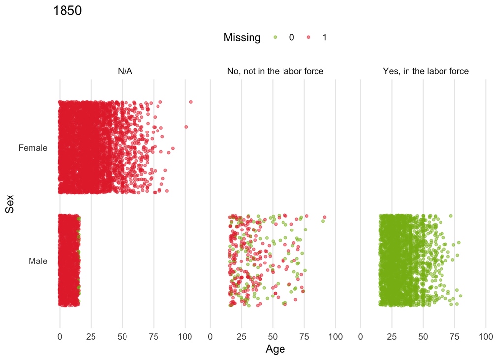

```r
s_1850 %>%
  mutate(miss_occ = ifelse(occ == 999,1,0)) %>%
  ggplot(aes(y = age, x = sex, col = factor(miss_occ))) +
  geom_jitter(alpha = 0.5,
              size = 1) +
  facet_wrap(~labforce) +

  scale_color_manual(values = col_miss) +

  labs(y = "Age", x = "Sex",
       col = "Missing", title = "1850") +
  theme(legend.position = "top",
        panel.grid.major.y = element_blank()) +
  coord_flip()
```

- Results show that there are no women who have an occupation code across all three levels of `labor force`
- There are also some `occ`s under the level of `N/A`, and “No, not in the labor force”, which are identified below.

##### `N/A` and `Male`

```r
s_1850 %>%
  filter(occ != 999 &
           labforce == "N/A") %>%
  group_by(label, occstr, sex) %>%
  summarise(count = n(), avg_age = mean(age)) %>%
  arrange(desc(count)) %>%
  kable() %>%
  kable_styling() %>%
  scroll_box(width = "100%", height = "300px")
```

| label | occstr | sex | count | avg_age |
| --- | --- | --- | --- | --- |
| Clerks in stores | CLERK | Male | 5 | 15 |
| Boot and shoemakers | SHOEMAKER | Male | 2 | 15 |
| Brass founders and workers | BRASS FOUNDER | Male | 2 | 15 |
| Butchers | BUTCHER | Male | 2 | 15 |
| Agricultural laborers | LABORER | Male | 1 | 15 |
| Artificial-flower makers | ARTIFICIAL FLOWERS | Male | 1 | 15 |
| Broom and brush makers | BRUSH MAKER | Male | 1 | 15 |
| Cigar makers | CIGAR MAKER | Male | 1 | 15 |
| Clerks in stores | HATTERS CLERK | Male | 1 | 15 |
| Employees of hotels and restaurants (not clerks) | WAITER | Male | 1 | 15 |
| Laborers (not specified) | LABORER | Male | 1 | 15 |
| Leather case and pocket-book makers | POCKET BOOKS | Male | 1 | 15 |
| Leather curriers, dressers, finishers, and tanners | MOROCCO STRETCHER | Male | 1 | 15 |
| Masons (brick and stone) | MASON | Male | 1 | 15 |
| Other non-occupational response | NONE | Male | 1 | 15 |
| Painters and varnishers | PAINTER | Male | 1 | 15 |
| Printers, lithographers, and stereotypers | PRINTER | Male | 1 | 15 |
| Sailors | SEAMAN | Male | 1 | 15 |
| Stock-drovers | DRIVES CATTLE | Male | 1 | 15 |
| Tailors and tailoresses | TAILOR | Male | 1 | 15 |

##### `No, not in the labor force` and `Male`

```r
s_1850 %>%
  filter(occ != 999 &
           labforce == "No, not in the labor force") %>%
  group_by(label, occstr) %>%
  summarise(count = n(), avg_age = mean(age)) %>%
  arrange(desc(count)) %>%
  kable() %>%
  kable_styling() %>%
  scroll_box(width = "100%", height = "300px")
```

| label | occstr | count | avg_age |
| --- | --- | --- | --- |
| Other non-occupational response | NONE | 73 | 44.67123 |
| Laborers (not specified) | @LABORER | 13 | 42.38462 |
| Student | STUDENT | 6 | 20.50000 |
| Sailors | SEAMAN | 5 | 28.20000 |
| Carpenters and joiners | CARPENTER | 2 | 33.00000 |
| Tailors and tailoresses | TAILOR | 2 | 49.00000 |
| Barbers and hairdressers | BARBER | 1 | 25.00000 |
| Blacksmiths | BLACKSMITH | 1 | 24.00000 |
| Cabinet makers | CHAIRS | 1 | 17.00000 |
| Cigar makers | CIGAR MAKER | 1 | 35.00000 |
| Copper workers | COPPER SMITH | 1 | 45.00000 |
| Draymen, hackmen, teamsters, etc. | HACK DRIVER | 1 | 48.00000 |
| Leather case and pocket-book makers | POCKET BOOKS | 1 | 17.00000 |
| Mark for allocation | [ROMTER | 1 | 25.00000 |
| Mark for allocation | COACH WHEELER | 1 | 30.00000 |
| Mark for allocation | COLEMAN | 1 | 43.00000 |
| Mark for allocation | GETISOR ? | 1 | 27.00000 |
| Mark for allocation | ROSERY | 1 | 33.00000 |
| Mark for allocation | SHOE DELARE | 1 | 30.00000 |
| Mark for allocation | SLIVER PLATER | 1 | 28.00000 |
| Mark for allocation | SLOTER | 1 | 29.00000 |
| Mark for allocation | STRAW WEAVER | 1 | 51.00000 |
| Mark for allocation | TIN PLATE W | 1 | 28.00000 |
| Masons (brick and stone) | MASON | 1 | 36.00000 |
| Nurses | ATTENDANT | 1 | 25.00000 |
| Officials, industry not specified | SUPERINTENDANT | 1 | 32.00000 |
| Other non-occupational response | REFRECTORY | 1 | 40.00000 |
| Painters and varnishers | PAINTER | 1 | 35.00000 |
| Painters and varnishers | SHADE PAINTER | 1 | 51.00000 |
| Porters and laborers in stores warehouses | PORTER | 1 | 22.00000 |
| Student | LAW STUDENT | 1 | 20.00000 |
| Student | MEDICAL STD | 1 | 19.00000 |
| Without occupation, unemployed | NONR | 1 | 16.00000 |

- A large majority of the green points were categorised as “Other non-occupational response”, providing little information, other than that these group of respondents were most probably indeed not in the labour force.
- There were also some labourers, which could be misclassified.
- There was a minority of students, which are indeed not in the labour force, but are considred to have an occupation under `occ`. It might be necessary to check if there are students who are in the “Yes, in the labor force” level.

#### 1880

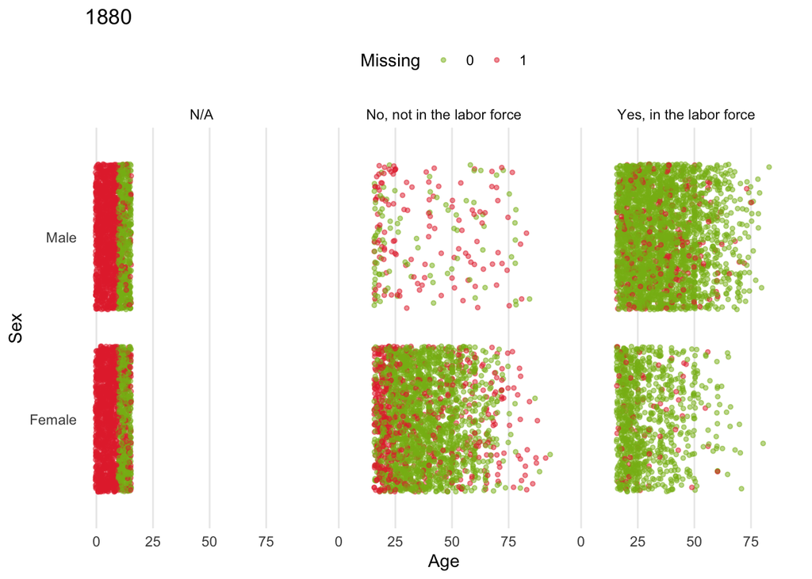

```r
s_1880 %>%
  mutate(miss_occ = ifelse(occ == 999,1,0)) %>%
  ggplot(aes(y = age, x = sex, col = factor(miss_occ))) +
  geom_jitter(alpha = 0.5,
              size = 1) +
  facet_wrap(~labforce) +

  scale_color_manual(values = col_miss) +

  labs(y = "Age", x = "Sex",
       col = "Missing", title = "1880") +
  theme(legend.position = "top",
        panel.grid.major.y = element_blank()) +
  coord_flip()
```

##### `N/A`

```r
s_1880 %>%
  filter(labforce == "N/A") %>%
  group_by(label,occstr, sex) %>%
  summarise(count = n(), avg_age = mean(age)) %>%
  arrange(desc(count)) %>%
  kable() %>%
  kable_styling() %>%
  scroll_box(width = "100%", height = "300px")
```

label

occstr

sex

count

avg_age

Blank

NA

Female

719

4.296245

Blank

NA

Male

690

4.010145

Student

AT SCHOOL

Female

314

12.041401

Student

AT SCHOOL

Male

301

11.767442

Blank

AT HOME

Female

238

5.533613

Blank

AT SCHOOL

Male

220

7.331818

Blank

AT SCHOOL

Female

209

7.224880

Blank

AT HOME

Male

167

4.449102

Student

SCHOOL

Female

43

11.790698

Blank

SCHOOL

Male

41

7.512195

Student

SCHOOL

Male

40

11.250000

Blank

SCHOOL

Female

37

7.675676

Blank

HOME

Female

30

3.200000

Blank

HOME

Male

30

2.400000

Domestic servants

SERVANT

Female

16

14.312500

Student

ATTENDING SCHOOL

Male

11

12.454546

Student

ATTENDS SCHOOL

Male

10

11.700000

Blank

ATTENDS SCHOOL

Female

9

7.000000

Messengers

ERRAND BOY

Male

8

14.375000

Blank

ATTENDS SCHOOL

Male

7

7.428571

Student

ATTENDING SCHOOL

Female

7

11.142857

Student

ATTENDS SCHOOL

Female

7

11.714286

Blank

ATTENDING SCHOOL

Female

6

6.833333

Blank

GOES TO SCHOOL

Female

6

6.166667

Clerks in stores

CLERK IN STORE

Male

6

14.500000

Other non-occupational response

HOME

Female

6

14.000000

Other non-occupational response

HOME

Male

6

12.333333

Student

GOES TO SCHOOL

Female

6

12.000000

Student

SCHOLAR

Male

5

11.000000

Blank

GOES TO SCHOOL

Male

4

7.250000

Messengers

OFFICE BOY

Male

4

14.250000

Student

SCHOLAR

Female

4

12.750000

Student

TO SCHOOL

Male

4

12.250000

Tailors and tailoresses

TAILORESS

Female

4

13.750000

Blank

INMATE

Female

3

6.666667

Blank

NONE

Female

3

6.000000

Blank

NONE

Male

3

4.000000

Blank

PUPIL-AT SCHOOL

Male

3

10.666667

Blank

SCHOLAR

Female

3

8.333333

Blank

SCHOLAR

Male

3

7.333333

Blank

ST. JOSEPH ORPHAN ASYLUM

Female

3

8.333333

Brass founders and workers

BRASS FINISHER

Male

3

15.000000

Clerks in stores

CLERK

Male

3

13.000000

Laborers (not specified)

LABORER

Male

3

14.666667

Milliners, dressmakers, and seamstresses

DRESS MAKER

Female

3

15.000000

Milliners, dressmakers, and seamstresses

SEAMSTRESS

Female

3

14.666667

Student

ATT. SCHOOL

Male

3

11.333333

Student

GOING TO SCHOOL

Male

3

11.000000

Blank

ATTENDING SCHOOL

Male

2

7.500000

Blank

LIVING HOME

Male

2

8.500000

Blank

PUPIL

Male

2

4.500000

Blank

TO SCHOOL

Female

2

6.500000

Domestic servants

DOMESTIC

Female

2

14.500000

Draymen, hackmen, teamsters, etc.

DRIVER

Male

2

15.000000

Employees of hotels and restaurants (not clerks)

WAITER

Male

2

13.000000

Messengers

CASH BOY

Male

2

13.500000

Other non-occupational response

NO OCCUPATION

Male

2

13.500000

Shirt, cuff, and collar makers

SHIRT MAKER

Female

2

15.000000

Student

PUPIL

Female

2

11.500000

Apprentices to trades

APP. TO CAST MAKER

Male

1

14.000000

Apprentices to trades

APP. TO POCKETBOOK MAKER

Male

1

15.000000

Apprentices to trades

APP. TO SAILMAKER

Male

1

15.000000

Apprentices to trades

APPR. IN BUTCHER SHOP

Male

1

15.000000

Apprentices to trades

APPRENTIC TO MACHINIST

Male

1

14.000000

Apprentices to trades

APPRENTICE ENGRAVER

Male

1

15.000000

Apprentices to trades

APPRENTICE ON DYEING

Male

1

14.000000

Apprentices to trades

APPRENTICE TO PLUMBER

Male

1

15.000000

Apprentices to trades

APPRENTICE TO THERMOMETER MAKER

Male

1

14.000000

Apprentices to trades

APPRENTICED TO FATHER

Male

1

15.000000

Apprentices to trades

APPRENTIST TO PRINTER

Male

1

15.000000

Apprentices to trades

DRESS MAKERS APPRENTICE

Male

1

15.000000

Apprentices to trades

LEARNING TELEGRAPHY

Male

1

15.000000

Apprentices to trades

PLUMBER APP.

Male

1

14.000000

Apprentices to trades

PRINTING APPREN’CE

Male

1

15.000000

Artificial-flower makers

ARTIFICAL FLOWERS

Female

1

14.000000

At home

ASSISTS AT HOME

Female

1

11.000000

At home

ASST. HOUSEKEEPER

Female

1

14.000000

Bakers

WORKS IN CRACKER BAKERY

Male

1

12.000000

Barbers and hairdressers

HAIR DRESSER

Female

1

15.000000

Barbers and hairdressers

HAIR DRESSING

Female

1

13.000000

Blank

Female

1

15.000000

Blank

A HOME

Female

1

5.000000

Blank

A SCHOOL

Male

1

6.000000

Blank

AT PLUMBING

Male

1

12.000000

Blank

ATT SCHOOL

Female

1

8.000000

Blank

ATTEND SCHOOL

Female

1

6.000000

Blank

ATTENDING BUTCHER SHOP

Male

1

12.000000

Blank

ATTENDS FANCY STORE

Female

1

15.000000

Blank

ATTG. SCHOOL

Female

1

13.000000

Blank

BOARDER

Female

1

3.000000

Blank

BOARDER

Male

1

0.000000

Blank

CIGAR …ER

Male

1

15.000000

Blank

CLERK IN WHOLESALE HOUSE

Male

1

15.000000

Blank

COMON LABORRER

Male

1

15.000000

Blank

DAUGHTER

Female

1

1.000000

Blank

DOCTORS ERRAND BOY

Male

1

15.000000

Blank

ERROND BOY IN STORE

Male

1

11.000000

Blank

FACTORY G.

Female

1

15.000000

Blank

FEATHER MAKING

Female

1

14.000000

Blank

FEATHER MAKING TRADE

Female

1

13.000000

Blank

FLAG BUSINESS

Male

1

14.000000

Blank

GO TO SCHOOL

Female

1

6.000000

Blank

GOING SCHOOL

Male

1

8.000000

Blank

GOING TO SCHOOL

Female

1

9.000000

Blank

GOING TO SCHOOL

Male

1

8.000000

Blank

IN LACE FACTORY

Female

1

14.000000

Blank

INMATE

Male

1

7.000000

Blank

KEEPING HOUSE

Female

1

1.000000

Blank

KEEPS HIS FATHER

Male

1

15.000000

Blank

KEEPS HOUSE

Female

1

3.000000

Blank

LARN A.F.

Female

1

13.000000

Blank

MEAT FACTORY

Male

1

15.000000

Blank

MERCHANT OFFICE BOY

Male

1

13.000000

Blank

MEUSICIAN

Male

1

14.000000

Blank

NAME

Male

1

4.000000

Blank

NUSE GIRL

Female

1

15.000000

Blank

NY

Female

1

0.000000

Blank

NY

Male

1

1.000000

Blank

ON SCHOOL

Male

1

10.000000

Blank

PACKING OYSTERS

Female

1

14.000000

Blank

PAINO FACT

Male

1

13.000000

Blank

PIPE MAKING

Male

1

14.000000

Blank

POCKET-BOOK MK

Male

1

14.000000

Blank

PUPIL-AT SCHOOL

Female

1

10.000000

Blank

SCHOOL/BOARDER

Female

1

10.000000

Blank

SCHOOLING

Male

1

9.000000

Blank

STOCKING FOLDING

Female

1

15.000000

Blank

STUDY AT HOME

Female

1

11.000000

Blank

TIN FAC

Female

1

13.000000

Blank

TOBACO FACT’Y HAND

Male

1

13.000000

Blank

UNEMPLOYED

Male

1

3.000000

Blank

WORK AT MAKIN FACTORY

Female

1

15.000000

Blank

WORK AT SILK FACTORY

Male

1

14.000000

Blank

WORKS AT BOOKFOLDING

Female

1

14.000000

Blank

WORKS AT HAIR NETS

Female

1

12.000000

Blank

WORKS AT LADIES GARMENTS

Female

1

15.000000

Blank

WORKS AT P.B.

Male

1

12.000000

Blank

WORKS AT PIANO MAKING

Male

1

14.000000

Blank

WORKS AT VALENTINES

Female

1

15.000000

Blank

WORKS IN HARP…

Male

1

15.000000

Blank

WORKS IN PLUMBER’S SHOP

Male

1

15.000000

Blank

WORKS IN ROPE FAC’T

Male

1

15.000000

Blank

WORKS IN SHOE BUSINESS

Male

1

14.000000

Blank

WORKS IN STORE BOARDER

Female

1

15.000000

Blank

WORKS ON NECKTIES

Female

1

12.000000

Blank

WORKS ON POCKET BKS

Male

1

13.000000

Blank

WORKS ON WOOSTED

Female

1

15.000000

Blank

WORKS WOLEN FACTORY

Female

1

14.000000

Bookbinders and finishers

BARKER

Male

1

10.000000

Bookbinders and finishers

BOOK BINDER

Female

1

14.000000

Bookbinders and finishers

BOOK BINDER

Male

1

14.000000

Boot and shoemakers

BOOT BLACK

Male

1

11.000000

Boot and shoemakers

WORK IN SHOE FACTORY

Male

1

13.000000

Boot and shoemakers

WORKS ON SHOES

Female

1

14.000000

Bottlers and mineral-water makers

BOTTLES BEER

Male

1

14.000000

Bottlers and mineral-water makers

WORKS IN SODA WATER FACTORY

Male

1

15.000000

Box factory operatives

WORKS AT PAPER BOXES

Female

1

15.000000

Brick and tile makers

BRICK MAKING

Male

1

15.000000

Broom and brush makers

WORKS AT BRUSHES

Male

1

15.000000

Cabinet makers

MAKING CHAIRS

Male

1

15.000000

Carpet makers

WORKS IN CARPET FAC

Female

1

15.000000

Carpet makers

WORKS IN CARPET FACTORY

Male

1

14.000000

Carpet makers

WORKS-CARPET FAC

Female

1

15.000000

Cigar makers

CIGAR MAKER

Male

1

15.000000

Clerks and bookkeepers in manufacturing estabs.

CLERK IN FENCE SHOP

Male

1

15.000000

Clerks and bookkeepers in manufacturing estabs.

STOCK CLERK

Male

1

13.000000

Clerks in stores

CLERK DRY GOODS

Male

1

15.000000

Clerks in stores

CLERK IN GROCERY

Male

1

13.000000

Clerks in stores

CLERK IN HAT STORE

Male

1

15.000000

Clerks in stores

CLERK IN SEGAR STORE

Male

1

14.000000

Clerks in stores

DRUG CLERK

Male

1

15.000000

Clerks in stores

HARDWARE CLERK

Male

1

15.000000

Coopers

COOPER

Male

1

15.000000

Domestic servants

DOMESTIC SERVANT

Female

1

14.000000

Draymen, hackmen, teamsters, etc.

TEAMSTER

Male

1

15.000000

Engravers

ENGRAVER

Male

1

15.000000

Glass-works operatives

WORKS IN GLASS FACTORY

Male

1

15.000000

Gold and silver workers and jewelers

WORKS FOR JEWELLER

Male

1

14.000000

Hucksters and peddlers

HUCKSTER

Male

1

15.000000

Institutional inmate

PATIENT

Female

1

11.000000

Keeping house

HOUSE KEEPING

Female

1

15.000000

Keeping house

KEEPING HOUSE

Female

1

15.000000

Keeping house

KEEPS HOUSE

Female

1

12.000000

Meat packers, curers, and picklers

WORKS IN SLAUGHTER HOUSE

Male

1

15.000000

Messengers

CASH GIRL IN STORE

Female

1

13.000000

Messengers

ERAND BOY

Male

1

15.000000

Messengers

MESSENGER

Male

1

13.000000

Milkmen and milkwomen

DRIVES MILK WAGON

Male

1

14.000000

Milkmen and milkwomen

MILK

Male

1

15.000000

Mill and factory operatives (not specified)

WORKING IN MILL

Female

1

15.000000

Mill and factory operatives (not specified)

WORKS IN FACTORY

Male

1

14.000000

Milliners, dressmakers, and seamstresses

DRESS MAKING

Female

1

15.000000

Milliners, dressmakers, and seamstresses

SEWING GIRL

Female

1

15.000000

Milliners, dressmakers, and seamstresses

WORKS FOR DRESSMAKER

Female

1

15.000000

Mirror and picture frame makers

WORKS AT FRAME MAKING

Male

1

14.000000

Newspaper criers and carriers

SELLS NEWSPAPERS

Male

1

11.000000

Nurses

NURSE

Female

1

14.000000

Other non-occupational response

LIVING HOME

Female

1

12.000000

Other non-occupational response

LIVING HOME

Male

1

12.000000

Other non-occupational response

NO OCCUPATION

Female

1

12.000000

Other non-occupational response

NONE

Female

1

10.000000

Other non-occupational response

WITHOUT OCCUPATION

Male

1

15.000000

Other non-occupational response

WITHOUT OCCUPTION

Female

1

15.000000

Packers

SEGAR PACKER

Female

1

14.000000

Painters and varnishers

PAINTER

Male

1

15.000000

Pianoforte makers and tuners

PIANO MAKER

Male

1

15.000000

Pianoforte makers and tuners

WORKS IN PIANO FACTORY

Male

1

15.000000

Porters and laborers in stores warehouses

WORKS IN FANCY STORE

Female

1

15.000000

Porters and laborers in stores warehouses

WORKS IN STORE

Female

1

13.000000

Publishers of books, maps, and newspapers

NEWSPAPER

Male

1

12.000000

Rope and cordage makers

ROPE MAKER

Male

1

13.000000

Rope and cordage makers

WORKS IN JUTE MILL

Female

1

13.000000

Rope and cordage makers

WORKS IN ROPE WALK

Male

1

13.000000

Saloon keepers and bartenders

ATTENDING BAR

Male

1

14.000000

Silk mill operatives

SILK WINDER

Female

1

15.000000

Student

ATT. SCHOOL

Female

1

13.000000

Student

ATTENDING SCHOLL

Female

1

14.000000

Student

COLLEGE

Male

1

15.000000

Student

GO TO SCHOOL

Male

1

12.000000

Student

GOES TO SCHOOL

Male

1

15.000000

Student

LAW STUDENT

Male

1

15.000000

Student

SCHOOL BOY

Male

1

12.000000

Student

STUDENT

Female

1

12.000000

Student

STUDENT

Male

1

14.000000

Student

TENDING SCHOOL

Female

1

15.000000

Tailors and tailoresses

COAT FINISHER

Female

1

12.000000

Tailors and tailoresses

TAILOR

Male

1

14.000000

Tailors and tailoresses

TAILORING

Female

1

14.000000

Tailors and tailoresses

TAILORIS

Female

1

14.000000

Tailors and tailoresses

VEST MAKER

Female

1

14.000000

Tailors and tailoresses

W. IN TAILOR SHOP

Female

1

13.000000

Tailors and tailoresses

WKS FOR TAILOR

Male

1

14.000000

Tailors and tailoresses

WORKS AT TAILOR SHOP

Female

1

14.000000

Tinners and tinware makers

WORKS IN TIN FACTORY

Male

1

14.000000

Tinners and tinware makers

WORKS IN TIN SHOP

Male

1

14.000000

Tobacco factory operatives

WORKS TOBACCO FACTORY

Female

1

13.000000

Traders and dealers (not specified)

VENDER

Male

1

14.000000

Traders and dealers in books stationary

STATIONER

Male

1

14.000000

Traders and dealers in dry foods, fancy foods, and notions

DRY GOODS STORE

Male

1

15.000000

Traders and dealers in iron, tin, and copperware

HARDWARE

Male

1

14.000000

Traders and dealers in newspapers periodicals

PAPER STAND

Male

1

15.000000

Traders and dealers in produce and provisions

MILK DEALER

Male

1

13.000000

Upholsterers

WORKS AT UPHOLSTERY

Male

1

15.000000

NA

CHAIR BOTTOMER

Female

1

14.000000

NA

FEATHER FACTORY

Female

1

13.000000

NA

LOOM BOY

Male

1

15.000000

NA

NECKTIE MAKER

Female

1

15.000000

NA

SEGAR BOX PASTER

Female

1

14.000000

NA

STRAW PRESSER

Male

1

15.000000

NA

WORKS AT BOOK FOLDING

Female

1

15.000000

NA

WORKS AT FRUITS

Female

1

13.000000

A large majority of the red points (missing `occ`s) were Blanks, which was expected

The majority of green points were students in both genders, which potentially shows a disparity in the coding styles between 1850 and 1880, as there were very little students in 1850.

It was also interesting that the average age of `N/A`s were under 15, which supports the earlier speculation that respondents under a certain threshold (possibly 16 years old), were categorised as `N/A` and not considered as officially being in the labour force.

##### `No, not in the labor force`

```r
s_1880 %>%
  filter(labforce == "No, not in the labor force") %>%
  group_by(label, occstr, sex) %>%
  summarise(count = n(), avg_age = mean(age)) %>%
  arrange(desc(count)) %>%
  kable() %>%
  kable_styling() %>%
  scroll_box(width = "100%", height = "300px")
```

label

occstr

sex

count

avg_age

Keeping house

KEEPING HOUSE

Female

1066

38.63884

Keeping house

KEEPS HOUSE

Female

351

37.99430

Blank

NA

Female

293

37.00683

Blank

AT HOME

Female

278

30.14388

Keeping house

KEEP HOUSE

Female

80

37.87500

Blank

NA

Male

62

37.06452

Keeping house

HOUSE KEEPING

Female

47

37.68085

Blank

AT HOME

Male

38

36.71053

Keeping house

HOUSE KEEPER

Female

33

37.72727

Keeping house

HOUSEKEEPER

Female

30

34.73333

Keeping house

HOUSEKEEPING

Female

29

41.37931

Other non-occupational response

HOME

Female

23

30.08696

Student

AT SCHOOL

Female

23

17.60870

Student

AT SCHOOL

Male

18

17.16667

At home

HOUSE WORK

Female

15

33.13333

Other non-occupational response

NONE

Female

15

36.80000

Other non-occupational response

NO OCCUPATION

Female

14

35.28571

Domestic servants

KEEPING HOUSE

Female

13

39.69231

Domestic servants

HOUSE KEEPER

Female

10

41.90000

Blank

BOARDING

Female

8

44.12500

Blank

BOARDER

Female

7

47.14286

Other non-occupational response

NO OCCUPATION

Male

7

46.28571

Retired

RETIRED

Male

7

58.28571

Other non-occupational response

NONE

Male

6

42.66667

Blank

KPG. HOUSE

Female

5

39.20000

Other non-occupational response

HOME

Male

5

17.40000

At home

HOUSEWORK

Female

4

29.75000

Keeping house

HOUSE KEEP

Female

4

32.00000

Keeping house

KEEPING H

Female

4

31.50000

Other non-occupational response

WITHOUT OCCUPATION

Female

4

23.00000

Retired

RETIRED MERCHANT

Male

4

55.75000

Student

SCHOOL

Female

4

18.00000

Student

SCHOOL

Male

4

16.75000

Student

STUDENT

Male

4

18.50000

Domestic servants

KEEPS HOUSE

Female

3

54.66667

Domestic servants

SERVANT

Female

3

45.66667

Keeping house

HOUSEWIFE

Female

3

55.33333

Keeping house

K. HOUSE

Female

3

32.33333

Keeping house

KEEPG HOUSE

Female

3

34.66667

Keeping house

KEEPING H.

Female

3

38.00000

Laborers (not specified)

LABORER

Male

3

34.66667

Retired

RETIRED FARMER

Male

3

76.33333

Blank

KEEP NONE HOUSE

Female

2

41.00000

Blank

KEEPS H.

Female

2

37.00000

Blank

KG. HOUSE

Female

2

38.50000

Blank

WITHOUT EMP.

Female

2

20.50000

Keeping house

KEEPING HOUE

Female

2

54.50000

Milliners, dressmakers, and seamstresses

SEWING

Female

2

23.00000

Nurses

NURSE

Female

2

19.00000

Other non-occupational response

NY

Female

2

24.00000

Retired

RETIRED MER.

Male

2

49.00000

Student

ATTENDING SCHOOL

Female

2

17.00000

At home

GEN. HOUSEWORK

Female

1

24.00000

At home

HELP TO MOTHER

Female

1

19.00000

At home

HELPS AT HOME

Female

1

17.00000

At home

HELPS HIS FATHER

Male

1

26.00000

At home

HOUSE

Female

1

31.00000

Blank

(BOARDER)

Female

1

44.00000

Blank

(RHEUMATISM)

Male

1

57.00000

Blank

Male

1

50.00000

Blank

AT HOME BOARDER

Female

1

45.00000

Blank

AT KEEPING HOUSE

Female

1

60.00000

Blank

BOARDING

Male

1

28.00000

Blank

BOARDING- NO OCCUPATION

Female

1

53.00000

Blank

BOOK …

Female

1

26.00000

Blank

BOORDING

Female

1

65.00000

Blank

CHARGE OF HOUSE

Female

1

30.00000

Blank

COLLEGE (AMHERST)

Male

1

20.00000

Blank

FANCY (…)

Female

1

36.00000

Blank

GOES TO COLLEGE

Male

1

16.00000

Blank

HEMETICALLY LEADED GOODS

Male

1

54.00000

Blank

K’P’G. HOUSE

Female

1

65.00000

Blank

KEEPG. HOUSE

Female

1

23.00000

Blank

KEEPING ALONE

Female

1

41.00000

Blank

KEEPING OF HOUSE

Female

1

54.00000

Blank

KEEPS (NONE) HOUSE

Female

1

29.00000

Blank

LAND POLEMAN

Male

1

30.00000

Blank

NO BUSNESS

Male

1

37.00000

Blank

NORMAL COLLEGE

Female

1

16.00000

Blank

PL?

Male

1

40.00000

Blank

RETIRE FRAME MAKER

Male

1

25.00000

Blank

RETIRED COM. MERCHANT

Male

1

50.00000

Blank

RETIRED CROCKERY DEALER

Female

1

69.00000

Blank

RETIRED DRY GOODS MCHT.

Male

1

77.00000

Blank

RETIRED FEED MILL

Male

1

60.00000

Blank

RETIRED FROM AUCTION BUSINESS

Male

1

70.00000

Blank

RETIRED MACHINST

Male

1

51.00000

Blank

RETIRED PIANO MAKER

Male

1

74.00000

Blank

RHEUMATIOUS, NO OCCUPATION

Male

1

45.00000

Blank

RITERED

Male

1

72.00000

Blank

RUTGART COLLEDGE

Male

1

24.00000

Blank

ST. JOSEPH ORPHAN ASYLUM

Female

1

19.00000

Blank

TAKING CARE OF WHAT HE HAS

Male

1

57.00000

Blank

WHITE…

Male

1

18.00000

Blank

WKS AT …

Male

1

19.00000

Blank

WOMEN

Female

1

60.00000

Blank

WORKS IN DRAVE YARD

Male

1

32.00000

Boarding- and lodging-house keepers

GOES OUT TO WORK

Female

1

60.00000

Boot and shoemakers

SHOEMAKER

Male

1

51.00000

Brass founders and workers

LANTERN MAKER

Male

1

20.00000

Butchers

BUTCHER

Male

1

27.00000

Button-factory operatives

KEEPING

Female

1

29.00000

Clergy

SISTER OF GOOD CHARITY

Female

1

38.00000

Domestic servants

DOMESTIC

Female

1

36.00000

Domestic servants

GOES OUT TO WORK

Female

1

40.00000

Domestic servants

HOUSE KEEPING

Female

1

73.00000

Domestic servants

HOUSEKEEPER

Female

1

50.00000

Domestic servants

HOUSEMAID

Female

1

31.00000

Domestic servants

KEEP HOUSE

Female

1

50.00000

Employees of hotels and restaurants (not clerks)

DAYS WORK

Female

1

50.00000

Engineers (civil)

UNKNOWN

Male

1

84.00000

Engineers and firemen

ENGINEER

Male

1

29.00000

Gentleman

LADY

Female

1

28.00000

Hucksters and peddlers

UNKNOWN

Male

1

26.00000

Institutional inmate

INMATE

Female

1

22.00000

Keeping house

H KEEPING

Female

1

36.00000

Keeping house

HOUSE KEEPER

Male

1

64.00000

Keeping house

HOUSE KEEPING GER

Female

1

28.00000

Keeping house

HOUSE KEEPS

Female

1

49.00000

Keeping house

HOUSE WIFE

Female

1

47.00000

Keeping house

HOUSEKEEKPER

Female

1

35.00000

Keeping house

K HOUSE

Female

1

40.00000

Keeping house

KEEPER OF HOUSE

Female

1

40.00000

Keeping house

KEEPING

Female

1

44.00000

Keeping house

KEEPING HOUSE

Male

1

65.00000

Keeping house

KEEPINGHOUSE

Female

1

46.00000

Keeping house

KEEPS HOME

Female

1

40.00000

Keeping house

UNKNOWN

Female

1

35.00000

Laborers (not specified)

HELPER

Male

1

21.00000

Launderers and laundresses

DAY WORK

Female

1

40.00000

Milliners, dressmakers, and seamstresses

ASST

Female

1

29.00000

Other non-occupational response

AT HOUSE

Female

1

27.00000

Other non-occupational response

DEAD

Male

1

70.00000

Other non-occupational response

DOES NOTHING

Female

1

17.00000

Other non-occupational response

IDLE

Male

1

19.00000

Other non-occupational response

LIVES WITH FAMILY

Female

1

19.00000

Other non-occupational response

LODGER

Male

1

26.00000

Other non-occupational response

NO BUSINESS

Female

1

25.00000

Other non-occupational response

NO BUSINESS

Male

1

43.00000

Other non-occupational response

UNEMPLOYED

Female

1

30.00000

Other non-occupational response

UNEMPLOYED

Male

1

42.00000

Other non-occupational response

UNOCCUPIED

Male

1

30.00000

Other non-occupational response

WIFE

Female

1

39.00000

Other non-occupational response

WITHOUT OCCUP.

Male

1

23.00000

Others in manufacturing, mechanical, and mining industries

FORMAN

Male

1

48.00000

Retired

RETIRED BROKER

Male

1

41.00000

Retired

RETIRED BUTCHER

Male

1

78.00000

Retired

RETIRED CLOTHING MERCHANT

Male

1

75.00000

Retired

RETIRED CONFECTIONER

Male

1

52.00000

Retired

RETIRED GROCER

Male

1

63.00000

Retired

RETIRED LAWYER

Male

1

52.00000

Student

AT COLLEGE

Male

1

19.00000

Student

ATTENDING SCHOOL

Male

1

19.00000

Student

ATTENDS SCHOOL

Male

1

16.00000

Student

GOES TO SCHOOL

Female

1

16.00000

Student

MEDICAL STUDENT

Male

1

22.00000

Student

PUPIL

Male

1

19.00000

Student

SCHOOL BOY

Male

1

16.00000

Tailors and tailoresses

TAILOR

Male

1

42.00000

Teachers and scientific persons

DO

Female

1

56.00000

Teachers and scientific persons

SCHOOL TEACHER

Female

1

24.00000

Traders and dealers in liquors and wines

DAY WORK

Female

1

43.00000

NA

ASS’T. HOUSEKEEPER

Female

1

35.00000

NA

HOUSE WORK HOME

Female

1

19.00000

The large red points in the data are to be expected

Other green points include `servants` and `Other non-occupational response`.

#### 1910

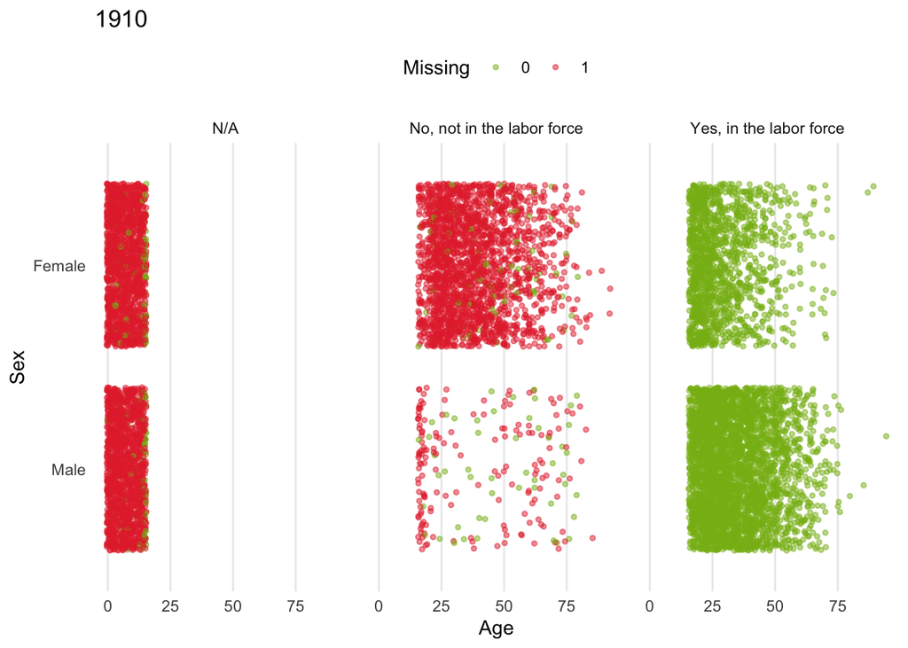

```r
s_1910 %>%
  mutate(miss_occ = ifelse(occ1950 == 999,1,0)) %>%
  ggplot(aes(y = age, x = sex, col = factor(miss_occ))) +
  geom_jitter(alpha = 0.5,
              size = 1) +
  facet_wrap(~labor_force) +

  scale_color_manual(values = col_miss) +

  labs(y = "Age", x = "Sex",
       col = "Missing", title = "1910") +
  theme(legend.position = "top",
        panel.grid.major.y = element_blank()) +
  coord_flip()
```

##### `N/A`

```r
s_1910 %>%
  filter(labor_force == "N/A") %>%
  group_by(label,sex) %>%
  summarise(count = n(), avg_age = mean(age)) %>%
  arrange(desc(count)) %>%
  kable() %>%
  kable_styling() %>%
  scroll_box(width = "100%", height = "300px")
```

| label | sex | count | avg_age |
| --- | --- | --- | --- |
| N/A (blank) | Female | 1433 | 6.808095 |
| N/A (blank) | Male | 1418 | 6.815938 |
| Not yet classified | Male | 35 | 10.542857 |
| Not yet classified | Female | 29 | 8.413793 |
| Operative and kindred workers (n.e.c.) | Female | 13 | 14.230769 |
| Messengers and office boys | Male | 12 | 14.666667 |
| At school/student | Male | 9 | 10.888889 |
| At school/student | Female | 6 | 8.500000 |
| Private household workers (n.e.c.) | Female | 6 | 14.666667 |
| Milliners | Female | 5 | 15.000000 |
| Operative and kindred workers (n.e.c.) | Male | 5 | 14.400000 |
| Salesmen and sales clerks (n.e.c.) | Female | 4 | 15.000000 |
| Laborers (n.e.c.) | Male | 3 | 14.666667 |
| Bookkeepers | Male | 2 | 11.500000 |
| Clerical and kindred workers (n.e.c.) | Female | 2 | 15.000000 |
| Tailors and tailoresses | Male | 2 | 15.000000 |
| Apprentices, building trades (n.e.c.) | Male | 1 | 14.000000 |
| Apprentices, other specified trades | Female | 1 | 15.000000 |
| Compositors and typesetters | Male | 1 | 15.000000 |
| Dressmakers and seamstresses, except factory | Female | 1 | 15.000000 |
| Entertainers (n.e.c.) | Male | 1 | 15.000000 |
| Other non-occupational response | Male | 1 | 7.000000 |
| Other non-occupational response | Female | 1 | 15.000000 |
| Stenographers, typists, and secretaries | Female | 1 | 15.000000 |
| Weavers, textile | Male | 1 | 15.000000 |

- Similar to 1880, a large proportion of the red points were “Blanks”, which was to be expected. This was followed by “Not yet classified” and some school students.
- The average age of those who had an occupation supports again that the census takers appeared to categorise youths as “N/A” instead of “No, not in the labor force”.

##### `No, not in the labor force`

```r
s_1910 %>%
  filter(labor_force == "No, not in the labor force") %>%
  group_by(label,occstr,sex) %>%
  summarise(count = n(), avg_age = mean(age)) %>%
  arrange(desc(count)) %>%
  kable() %>%
  kable_styling() %>%
  scroll_box(width = "100%", height = "300px")
```

| label | occstr | sex | count | avg_age |
| --- | --- | --- | --- | --- |
| N/A (blank) | NA | Female | 2082 | 37.97646 |
| N/A (blank) | NA | Male | 162 | 38.79012 |
| Gentleman/lady/at leisure | OWN INCOME | Female | 38 | 52.05263 |
| Gentleman/lady/at leisure | OWN INCOME | Male | 22 | 63.72727 |
| Keeps house/housekeeping at home/housewife | NA | Female | 9 | 34.44444 |
| Other non-occupational response | UN | Male | 7 | 35.85714 |
| At school/student | STUDENT | Male | 5 | 19.80000 |
| Keeps house/housekeeping at home/housewife | HOUSEWIFE | Female | 5 | 33.00000 |
| Other non-occupational response | NA | Female | 5 | 47.00000 |
| Retired | RETIRED | Male | 5 | 59.80000 |
| Keeps house/housekeeping at home/housewife | HOUSE WORK | Female | 3 | 42.00000 |
| Other non-occupational response | NA | Male | 3 | 63.00000 |
| At school/student | STUDENT | Female | 2 | 17.50000 |
| Gentleman/lady/at leisure | INCOME | Female | 2 | 44.50000 |
| Keeps house/housekeeping at home/housewife | HOUSEWORK | Female | 2 | 42.00000 |
| Private household workers (n.e.c.) | SERVANT | Female | 2 | 59.50000 |
| At school/student | NA | Male | 1 | 24.00000 |
| Carpenters | CARPENTER | Male | 1 | 40.00000 |
| Gentleman/lady/at leisure | OWN | Female | 1 | 50.00000 |
| Gentleman/lady/at leisure | OWN MEANS | Female | 1 | 60.00000 |
| Inmate | MILITARY PRISONER | Male | 1 | 30.00000 |
| Inmate | NA | Female | 1 | 71.00000 |
| Keeps house/housekeeping at home/housewife | HOME | Female | 1 | 43.00000 |
| Keeps house/housekeeping at home/housewife | HOUSEHOLD | Female | 1 | 29.00000 |
| Laborers (n.e.c.) | LABORER | Male | 1 | 30.00000 |
| Not yet classified | SEW MACH OP | Female | 1 | 16.00000 |
| Not yet classified | NA | Male | 1 | 22.00000 |
| Not yet classified | NA | Female | 1 | 54.00000 |
| Nurses, student professional | NURSE | Female | 1 | 21.00000 |
| Other non-occupational response | NON | Female | 1 | 47.00000 |
| Plumbers and pipe fitters | PLUMBER | Male | 1 | 18.00000 |
| Retired | RETIRED | Female | 1 | 21.00000 |
| Retired | NA | Male | 1 | 62.00000 |
| Taxicab drivers and chauffers | DRIVER | Male | 1 | 34.00000 |

- The majority of red points were to be expected and were ideal.
- The minority of green points were “Gentleman/lady/at leisure”, which appears to be some variation of “Retired”, given that this group had a much higher average age.